# Multi-omics integration

# Introduction and Dataset

Multi-omics integration is a field with potential for nearly any research question aiming at understand biological mechanisms. With the advance in biomolecule detection technologies, there is abundance and increasing variety of what can be captured in a living system. Integration has challenges due to the variability between what and how each method captures the biological signal. A small example of that is the difference in scale between single cell transcriptomics (thousands of genes) and single cell proteomics (only hundreds of genes), which makes pairing these methods not feasible in many cases. One way to group integration methods is based on the anchor shared by all OMICS method. In **Vertical/matched Integration** all methods are generated from (i.e anchored on) the same sample set. **Unmatched/diagonal Integration** is probably the hardest because each OMICS is generated using different sample due to easier handling etc. **Mosaic Integration** is the case of analysing different samples using mutli-OMICS with some overlap between the used methods (e.g trans/proteomics for one sample, trans/epigenomics for the other). Here, we discuss the first approach, vertical integration.

Methylation is a one of the most important epigenetic modifications that happen in the genome, where a methyl group is added to cytosine bases -especially in CpG sites found near promoter regions- by enzyme group called DNA methyltransferases (DNMTs). This modification regulates the expression of DNA (i.e genes) by preventing transcription factors from binding to the DNA. Mapping these modification patterns is one of the established methods for identifying tumor classes in Cancer research. Combined with other sequencing methods such as RNA-seq and Whole Exome Seq, , we obtain an overview of a disease and reach better understanding of the biological mechanism underlying it. Colorectal Cancer is one of the most common cancers worldwide. The dataset used here consists of two subtypes of (CMS1 and CMS3) 121 tumors obtained from the TCGA colorectal cancer cohort in the Pan-Cancer project ([Weinstein et al. 2013](https://www.nature.com/articles/ng.2764)) in three modalitlies: RNA-seq, Exome-seq and Copy Number Variation.

### Importing all data modalities

```r
# RNA-seq
csv_rna_seq = system.file("extdata", "multi-omics", "COREAD_CMS13_gex.csv", package="compGenomRData")

RnaSeq_data = read.csv(csv_rna_seq, row.names=1)

head(RnaSeq_data[,1:5],5)
```

```
         TCGA.A6.2672 TCGA.A6.3809 TCGA.A6.5661 TCGA.A6.5665 TCGA.A6.6653
RNF113A      21.19567     21.50866     20.08072      0.00000      0.00000
S100A13      19.72600     18.65729     18.97034     11.88336     12.07753
AP3D1        11.53022     12.98830     10.83759     10.24248      0.00000
ATP6V1G1      0.00000     14.12675     15.31325     19.79300      0.00000
UBQLN4       15.35637     19.62208      0.00000      0.00000      0.00000
```

**Note:** The decimal values are *RPKM* (Read Per Kilobase of transcript Per Million mapped reads), formula is:
$$\text{RPKM} = \frac{\text{Gene Read Count}}{\left(\frac{\text{Total Mapped Reads}}{1{,}000{,}000}\right) \times \left(\frac{\text{Gene Length in bp}}{1{,}000}\right)} = \frac{\text{Gene Read Count} \times 10^9}{\text{Total Mapped Reads} \times \text{Gene Length in bp}}$$

```r
# WES
csv_wes = system.file("extdata", "multi-omics", "COREAD_CMS13_muts.csv",
                       package="compGenomRData")
wes_data = read.csv(csv_wes, row.names=1)

# Set mutation data to be binary (i.e if a gene has more than 1 mutation, we only count one)
wes_data[wes_data>0]=1

head(wes_data[,1:5],5)
```

```
      TCGA.A6.2672 TCGA.A6.3809 TCGA.A6.5661 TCGA.A6.5665 TCGA.A6.6653
TTN              1            1            1            1            1
TP53             0            0            0            0            0
APC              0            0            0            0            0
KRAS             0            0            0            0            1
SYNE1            1            0            1            1            0
```

**Note:** that the original data includes decimal values between 0,1. These are likely mutation counts per gene normalized by either coding sequence or gene length. For simplicity, we assume that any non-zero value signifies a mutation in the gene.

```r
# CNV
csv_cnv = system.file("extdata", "multi-omics", "COREAD_CMS13_cnv.csv", package="compGenomRData")

cnv_data = read.csv(csv_cnv, row.names=1)

head(cnv_data[,8:14],5)
```

```
       TCGA.AA.3502 TCGA.AA.3655 TCGA.AA.3663 TCGA.AA.3664 TCGA.AA.3672
8p23.2    0.1118034            0    0.1118034    0.0000000            0
8p23.3    0.1212678            0    0.1212678    0.0000000            0
8p23.1    0.1186782            0    0.1186782    0.0000000            0
8p21.3    0.1203859            0    0.1203859    0.2407717            0
8p12      0.1259882            0    0.1259882    0.1259882            0
       TCGA.AA.3680 TCGA.AA.3713
8p23.2    0.0000000    0.1118034
8p23.3    0.0000000    0.1212678
8p23.1    0.2373563    0.1186782
8p21.3    0.2407717    0.1203859
8p12      0.1259882    0.1259882
```

**Note:** The decimal values are the *GISTIC scores* (Genomic Identification of Significant Targets in Cancer), they calculated by an algorithm that combines the frequency of CNV and the amplitude (copy number losses/gains) per locus across samples. The loci names are band locations in chromosomes. In contrast to the other data types, where measurements reflect a biological event of expression or mutation, this one reflects a consequence of genomic instability induced by the process of carcinogenesis where genomic rearrangements alter the number of DNA segments.

```r
# subtype of each sample
csv_subtypes = system.file("extdata", "multi-omics", "COREAD_CMS13_subtypes.csv", package="compGenomRData")

covariates = read.csv(csv_subtypes, row.names=1)

# Fix the TCGA identifiers so they match up with the data
rownames(covariates) = gsub(pattern = '-', replacement = '\\.', rownames(covariates))

# reorder the samples entries for proper labelling
covariates = covariates[colnames(RnaSeq_data),]

# create a dataframe which will be used to annotate later graphs
anno_col = data.frame(cms=as.factor(covariates$cms_label))
rownames(anno_col) = rownames(covariates)
head(covariates[,1:5])
```

```
             dataset age gender stage pt
TCGA.A6.2672    tcga  82 female     3  3
TCGA.A6.3809    tcga  71 female     2  4
TCGA.A6.5661    tcga  80 female     2  3
TCGA.A6.5665    tcga  84 female     2  3
TCGA.A6.6653    tcga  82   male     1  2
TCGA.A6.6780    tcga  74   male     2  3
```

The covariates data include the following variables:

[output not shown]

The first exploratory task to do is plotting heatmaps to see the patterns in the data and if sample groups cluster together.

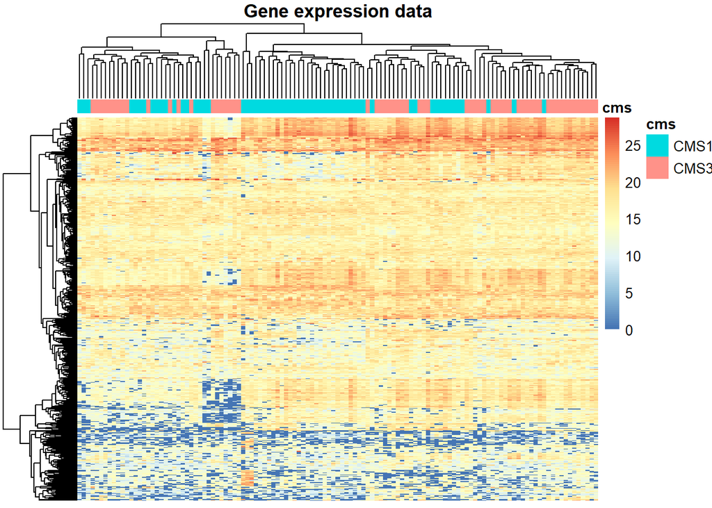

```r
# gene expression heatmap annotated with sample subtype
pheatmap::pheatmap(RnaSeq_data, annotation_col = anno_col, show_colnames = FALSE, show_rownames = FALSE, main="Gene expression data")
```

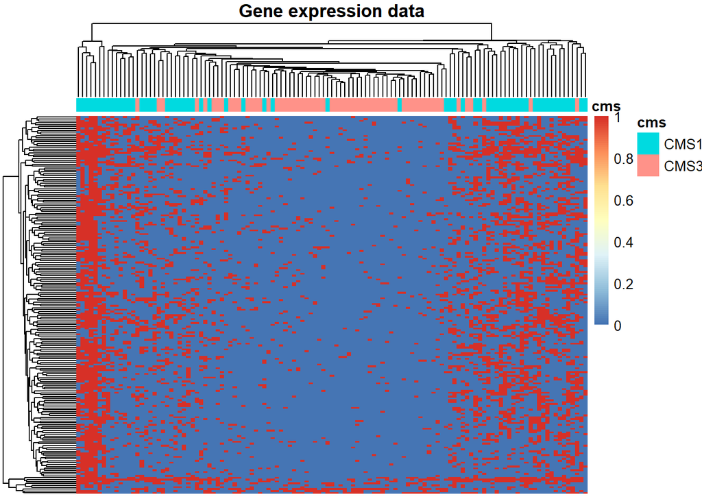

```r
# mutation heatmap annotated with sample subtype
pheatmap::pheatmap(wes_data, annotation_col = anno_col, show_colnames = FALSE, show_rownames = FALSE, main="Gene expression data")
```

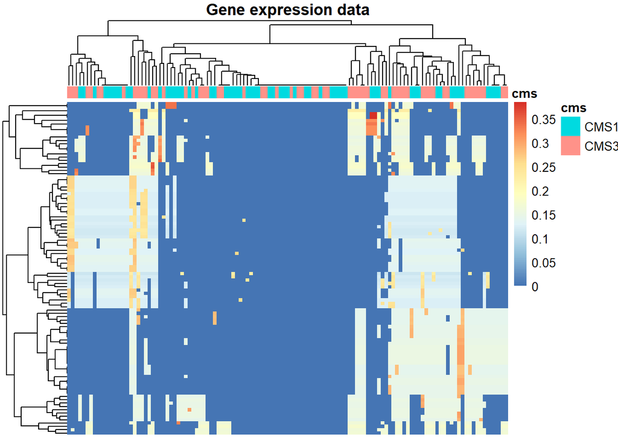

```r
# CNV heatmap annotated with sample subtype
pheatmap::pheatmap(cnv_data, annotation_col = anno_col, show_colnames = FALSE, show_rownames = FALSE, main="Gene expression data")
```

Looking into the threes heatmaps; no single method can differentiate samples and provide a clear explanation of what drives the differentiation to one of the subtypes. Combining these three data types, the aim is to obtain a better understanding of the biological process leading to differentiation.

# Integration Analysis

### Multiple Factor Analysis

To begin with, I believe it helps to simplify the terminology used in this domain. **Latent Variable Models**, is a class of unsupervised statistical approaches that functions as dimensionality reduction in multi-omics integration. Latent variables refer to hidden factors that underline the characteristics of observed data but are unobserved (hence “latent”). These factors differ from experiment/data type to another, in the case of **Bulk-RNA-seq**, RNA is extracted from multiple cells in a tissue and multiplexed, which means that we can no more observe the cell type in our final measurement despite having important impact on the abundance of RNA molecules. To obtain these latent variables we use **Matrix Factorization** which is family of LVMs,that infers a set of latent variables by factorizing/breaking down the data matrix into smaller pieces. When applying **Principal Component Analysis** over the multi-dimensional data we end up having a matrix factorization. **Singular Value Decomposition** is one of the algorithms used to compute PCA.

Second, we now consider how we can combine the three modalities together. The first problem faced is the different in scale between data types. **Multiple factor Analysis** solves this by first normalizing each matrix/data on its own before stacking/joining them to a single giant matrix. MFA does the scaling by z-standardization automatically then applies PCA (with SVD) for each data type seperately, calculates the first eigenvalue and normalizes all variables over their respective first eigenvalue. Recalling that eigenvalue is a scalar that describes variation of each PC (1 in this case), this means that each data weighted by the variance of its 1st PC. The final result looks like this, 𝜆𝑖 is the first eigenvalue of the principal component decomposition of 𝑋𝑖.

$$X_n =\begin{bmatrix}X_1 / \sqrt{\lambda_1^{(1)}} \\X_2 / \sqrt{\lambda_1^{(2)}} \\\vdots \\X_L / \sqrt{\lambda_1^{(L)}}\end{bmatrix}= WH$$

```r
# scaling with z-standardization, then normalization over PC1 variance
# mfa expects sample x variable, so need to transpose
mfa_res = FactoMineR::MFA(base = t(rbind(RnaSeq_data, wes_data, cnv_data)),
                      group = c(dim(RnaSeq_data)[1], dim(wes_data)[1], dim(cnv_data)[1]),
                      type = c("s", "c", "s"), graph=FALSE)
```

**Note:** The original implementation uses the default data `type = "s"` which is wrong because `wes_data` is binary/categorical, and using `"s"` will lead to standardizing binary values and distorting the weight of genes and can even return error due to 0-divisiob of genes with no mutations (i.e zero variance). While `"n"` is the ideal value and requires transforming values to R factors, it is better swapped for `"c"` because it scales without standardizing.

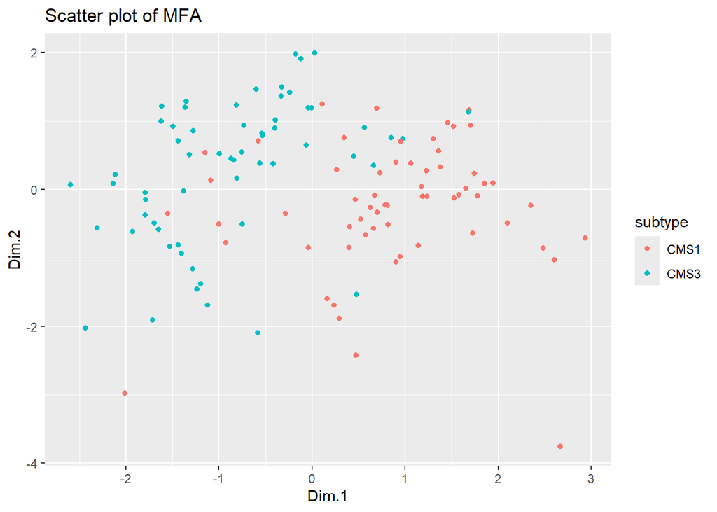

```r
# extract the H and W matrices from MFA result
mfa_h = mfa_res$global.pca$ind$coord
mfa_w = mfa_res$quanti.var$coord

# create a dataframe with the H matrix and the CMS label
mfa_df = as.data.frame(mfa_h)
mfa_df$subtype = factor(covariates[rownames(mfa_df),]$cms_label)

# create the plot
ggplot2::ggplot(mfa_df, ggplot2::aes(x=Dim.1, y=Dim.2, color=subtype)) +
ggplot2::geom_point() + ggplot2::ggtitle("Scatter plot of MFA")
```

Dimensionality reduction helped in distinguishing the samples over a linear combination of the variables (i.e the principal components). `mfa()` applied a PCA over each modality then joined them and applied a PCA, thus the resulting principle components are representative of all modalities.

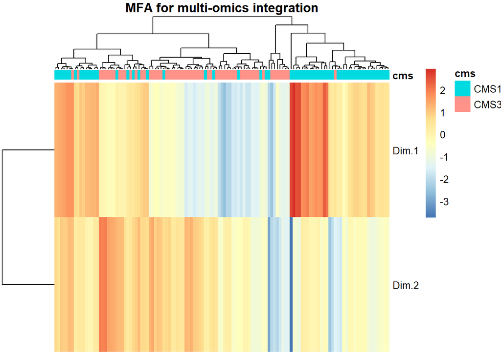

```r
# heatmap of PC1 & 2
pheatmap::pheatmap(t(mfa_h)[1:2,], annotation_col = anno_col,
                  show_colnames = FALSE, main="MFA for multi-omics integration")
```

### Joint Non-negative Matrix Factorization

$$X =
\begin{bmatrix}
X_1^N / \alpha_1 \\
X_2^N / \alpha_2 \\
\vdots \\
X_L^N / \alpha_L
\end{bmatrix},$$

```r
# Feature-normalize the data
RnaSeq_data_featnorm = RnaSeq_data / rowSums(RnaSeq_data)
wes_data_featnorm = wes_data / rowSums(wes_data)
cnv_data_featnorm = cnv_data / rowSums(cnv_data)

# Normalize by each omics type's frobenius norm
RnaSeq_data_frobnorm = RnaSeq_data_featnorm / norm(as.matrix(RnaSeq_data_featnorm), type="F")
wes_data_frobnorm = wes_data_featnorm / norm(as.matrix(wes_data_featnorm), type="F")
cnv_data_frobnorm = cnv_data_featnorm / norm(as.matrix(cnv_data_featnorm), type="F")
```

```r
# run NMF
nmf_result = NMF::nmf(t(rbind(RnaSeq_data_frobnorm, wes_data_frobnorm, cnv_data_frobnorm)),2, method='Frobenius')

# exctract the H and W matrices from the nmf run result
nmf_h = NMF::basis(nmf_result)
nmf_w = NMF::coef(nmf_result)
nmfw = t(nmf_w)
```

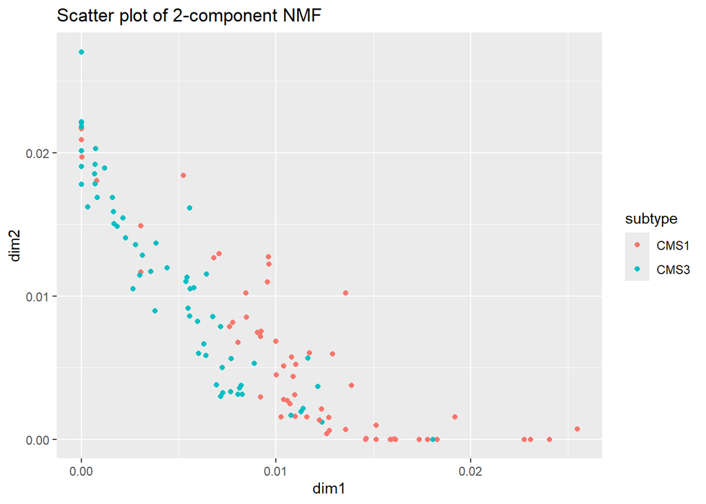

```r
# create a dataframe with the H matrix and the CMS label (subtype)
nmf_df = as.data.frame(nmf_h)
colnames(nmf_df) = c("dim1", "dim2")
nmf_df$subtype = factor(covariates[rownames(nmf_df),]$cms_label)

# create the scatter plot
ggplot2::ggplot(nmf_df, ggplot2::aes(x=dim1, y=dim2, color=subtype)) +
ggplot2::geom_point() +
ggplot2::ggtitle("Scatter plot of 2-component NMF")
```

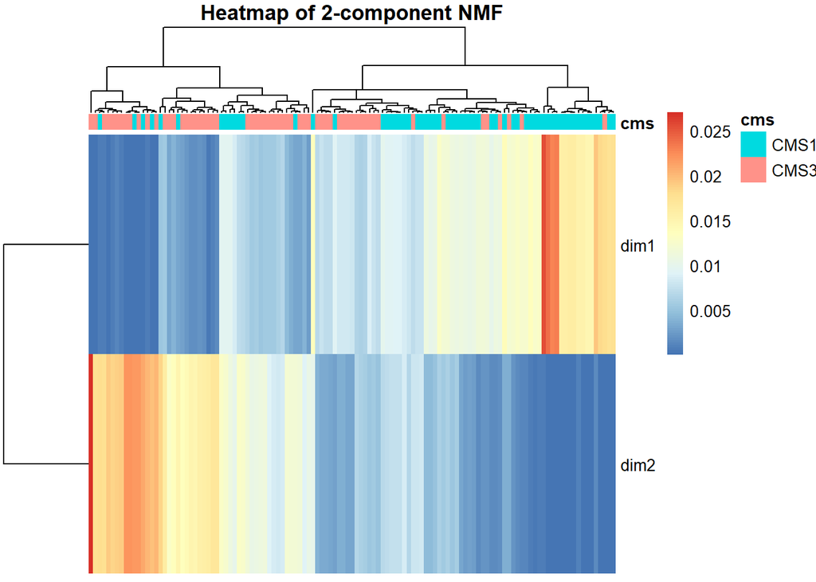

```r
pheatmap::pheatmap(t(nmf_df[,1:2]), annotation_col = anno_col, show_colnames=FALSE,
                   main="Heatmap of 2-component NMF")
```

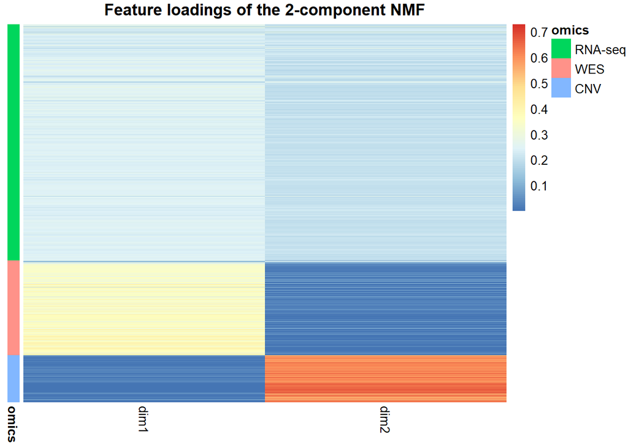

```r
# feature loadings: features x 2
nmf_loadings = t(NMF::coef(nmf_result))
colnames(nmf_loadings) = c("dim1", "dim2")

# omics label for each row, in the same order as the rbind()
omics_type = rep(c("RNA-seq", "WES", "CNV"),
                 times = c(nrow(RnaSeq_data), nrow(wes_data), nrow(cnv_data)))

# make row names unique (the same gene can occur in several layers)
rownames(nmf_loadings) = paste(omics_type, rownames(nmf_loadings), sep = "_")

anno_row = data.frame(omics = factor(omics_type, levels = c("RNA-seq", "WES", "CNV")),
                      row.names = rownames(nmf_loadings))

pheatmap::pheatmap(nmf_loadings, annotation_row = anno_row,
                   show_rownames = FALSE, cluster_cols = FALSE, cluster_rows = FALSE,
                   main = "Feature loadings of the 2-component NMF")
```

[figure not shown]

```r
# feature weights/coefficients
omics_means = rowsum(nmf_loadings, group = omics_type) / as.vector(table(omics_type)[unique(omics_type)])
pheatmap::pheatmap(omics_means, cluster_rows = FALSE, cluster_cols = FALSE,
                   display_numbers = TRUE, main = "Mean weights per omics type")
```